# Анализ поведения пользователей в мобильном приложении "Ненужные вещи"

### Цель:

**Получить на основе поведения пользователей гипотезы о том, как можно было бы улучшить приложение с точки зрения пользовательского опыта.**

### Описание данных:

Датасет содержит данные о событиях, совершенных в мобильном приложении "Ненужные вещи". В нем пользователи продают свои ненужные вещи, размещая их на доске объявлений. В датасете содержатся данные пользователей, впервые совершивших действия в приложении после 7 октября 2019 года.

### Этапы исследования:

#### Предобработка данных

1. Исследовать пропущенные значения
2. Исследовать соответствие типов
3. Исследовать дубликаты
4. Проверить корректность наименований колонок
5. Переименовать колонки
6. Удалить дубликаты
7. Привести типы
8. Заменить пропущенные значения

#### Анализ предшествующих действий

1. Выявить сессии пользователей
2. Определить последовательности действий пользователей, которые предшествуют просмотру контактов (contacts_show и show_contacts).
3. В разрезе сессий отобрать сценарии\паттерны, которые приводят к просмотру контактов **(обязательно)**
4. Построить воронки по основным сценариям в разрезе уникальных пользователей **(обязательно)**
5. Построить диаграмму Санкей для визуализации последовательностей действий, ведущих к просмотру контактов.

#### Исследовательский анализ данных

1. Оценка частоты действий пользователей, которые просматривают контакты **(обязательно)**
   - Рассчитать относительную частоту событий в разрезе двух групп пользователей:

     ```
       - группа пользователей, которые смотрели контакты contacts_show

       - группа пользователей, которые не смотрели контакты contacts_show
     ```

2. Источники установки приложения
   - Изучить как источник установки приложения влияет на поведение пользователей и их действия.
   - Проанализировать скорость выполнения целевого действия в зависимости от источника установки.
3. Факторы, влияющие на целевое действие
   - Определить ключевые факторы, которые влияют на просмотр контактов.

#### Статистические гипотезы

Проверить следующие гипотезы:

1. Различается ли конверсия в просмотры контактов у пользователей, которые совершают действия tips_show и tips_click, по сравнению с теми, кто совершает только tips_show.
2. Различается ли среднее время, прошедшее с начала сессии до просмотра контактов, для пользователей из разных источников установки.

#### Общий вывод

1. Подготовить рекомендации на основе полученных результатов
2. Подготовить обобщающую презентацию

### Оглавление

1. Открытие данных
2. Предобработка данных
3. Анализ предшествующих действий
   - Диаграмма Сэнкей
   - Воронки по основным сценариям
4. Исследовательский анализ данных
5. Статистические гипотезы
6. Общий вывод

```python
!pip install scikit-posthocs

import pandas as pd
import numpy as np
from collections import deque
from tqdm import tqdm
import plotly.express as px
import plotly.graph_objects as go
import seaborn as sns
import matplotlib.pyplot as plt
from scipy import stats as st
import math as mth
import scikit_posthocs as sp
```

## Открытие данных

```python
mobile_dataset = pd.read_csv('datasets/mobile_dataset.csv')
mobile_dataset.head()
```

|  | event.time | event.name | user.id |
| --- | --- | --- | --- |
| 0 | 2019-10-07 00:00:00.431357 | advert_open | 020292ab-89bc-4156-9acf-68bc2783f894 |
| 1 | 2019-10-07 00:00:01.236320 | tips_show | 020292ab-89bc-4156-9acf-68bc2783f894 |
| 2 | 2019-10-07 00:00:02.245341 | tips_show | cf7eda61-9349-469f-ac27-e5b6f5ec475c |
| 3 | 2019-10-07 00:00:07.039334 | tips_show | 020292ab-89bc-4156-9acf-68bc2783f894 |
| 4 | 2019-10-07 00:00:56.319813 | advert_open | cf7eda61-9349-469f-ac27-e5b6f5ec475c |

```python
mobile_dataset.info()
```

```
<class 'pandas.core.frame.DataFrame'>
RangeIndex: 74197 entries, 0 to 74196
Data columns (total 3 columns):
 #   Column      Non-Null Count  Dtype
---  ------      --------------  -----
 0   event.time  74197 non-null  object
 1   event.name  74197 non-null  object
 2   user.id     74197 non-null  object
dtypes: object(3)
memory usage: 1.7+ MB
```

```python
mobile_sourсes = pd.read_csv('datasets/mobile_sourсes.csv')
mobile_sourсes.head()
```

|  | userId | source |
| --- | --- | --- |
| 0 | 020292ab-89bc-4156-9acf-68bc2783f894 | other |
| 1 | cf7eda61-9349-469f-ac27-e5b6f5ec475c | yandex |
| 2 | 8c356c42-3ba9-4cb6-80b8-3f868d0192c3 | yandex |
| 3 | d9b06b47-0f36-419b-bbb0-3533e582a6cb | other |
| 4 | f32e1e2a-3027-4693-b793-b7b3ff274439 | google |

```python
mobile_sourсes.info()
```

```
<class 'pandas.core.frame.DataFrame'>
RangeIndex: 4293 entries, 0 to 4292
Data columns (total 2 columns):
 #   Column  Non-Null Count  Dtype
---  ------  --------------  -----
 0   userId  4293 non-null   object
 1   source  4293 non-null   object
dtypes: object(2)
memory usage: 67.2+ KB
```

## Предобработка данных

Тип колонки event.time - object, поэтому стоит привести дату/время к правильному формату

```python
mobile_dataset['event.time'] = pd.to_datetime(mobile_dataset['event.time'], format='%Y-%m-%d %H:%M:%S.%f')
```

Переименуем колонки mobile_dataset для удобства

```python
mobile_dataset = mobile_dataset.rename(columns={'event.time': 'event_time', 'event.name': 'event_name', 'user.id': 'user_id'})
```

Переименуем колонки mobile_sourсes для удобства

```python
mobile_sourсes = mobile_sourсes.rename(columns={'userId': 'user_id'})
```

Проверим количество уникальных пользователей в mobile_dataset

```python
print('Количество уникальных пользователей в mobile_dataset: {}'.format(mobile_dataset['user_id'].nunique()))
```

```
Количество уникальных пользователей в mobile_dataset: 4293
```

Количество пользователей, пришедших из разных источников

```python
mobile_sourсes['source'].value_counts()
```

```
yandex    1934
other     1230
google    1129
Name: source, dtype: int64
```

Проверим наличие дубликатов и пропущенных значений

```python
print('Дубликаты в mobile_dataset: {}'.format(any(mobile_dataset.duplicated())))
print('Дубликаты в mobile_sourсes: {}'.format(any(mobile_sourсes.duplicated())))
```

```
Дубликаты в mobile_dataset: False
Дубликаты в mobile_sourсes: False
```

```python
print('Дубликаты user_id в mobile_sourсes: {}'.format(any(mobile_sourсes['user_id'].duplicated())))
```

```
Дубликаты user_id в mobile_sourсes: False
```

```python
print('Доля пропущенных значений в mobile_dataset:')
print(round(mobile_dataset.isna().mean(),2))
print()
print('Доля пропущенных значений в mobile_sources:')
print(round(mobile_sourсes.isna().mean(),2))
```

```
Доля пропущенных значений в mobile_dataset:
event_time    0.0
event_name    0.0
user_id       0.0
dtype: float64

Доля пропущенных значений в mobile_sources:
user_id    0.0
source     0.0
dtype: float64
```

В описании говорится, что в датасете содержатся данные пользователей, впервые совершивших действия в приложении после 7 октября 2019 года. Проверим, так ли это

```python
print("Самая ранняя дата совершенного действия: {}".format(mobile_dataset['event_time'].min()))
print("Самая поздняя дата совершенного действия: {}".format(mobile_dataset['event_time'].max()))
```

```
Самая ранняя дата совершенного действия: 2019-10-07 00:00:00.431357
Самая поздняя дата совершенного действия: 2019-11-03 23:58:12.532487
```

Посмотрим количество повторений определенного действия

```python
mobile_dataset['event_name'].value_counts()
```

```
tips_show        40055
photos_show      10012
advert_open       6164
contacts_show     4450
map               3881
search_1          3506
favorites_add     1417
search_5          1049
tips_click         814
search_4           701
contacts_call      541
search_3           522
search_6           460
search_2           324
search_7           222
show_contacts       79
Name: event_name, dtype: int64
```

Т.к. действий, связанных с поиском по сайту, не так много, стоит объединить их. Также объединим оба целевых действия

```python
mobile_dataset.loc[mobile_dataset['event_name'].str.contains('search'), 'event_name'] = 'search'
mobile_dataset.loc[mobile_dataset['event_name'].str.contains('show_contacts'), 'event_name'] = 'contacts_show'
```

#### Вывод

- В данных отсутствуют явные дубликаты и дубликаты в user_id, а также пропущенные значения
- Количество уникальных пользователей в mobile_dataset - 4293. Столько же записей в mobile_sourсes, следовательно, для каждого пользователя существует сессия
- Пользователи приходят из yandex, google и прочих источников
- Самая ранняя дата совершенного действия - 7 октября 2019 года, а самая поздняя - 3 ноября 2019 года

## Анализ предшествующих действий

```python
# создаем сессии
mobile_dataset = mobile_dataset.sort_values(by=['user_id', 'event_time'])
groups = (mobile_dataset.groupby('user_id')['event_time'].diff() > pd.Timedelta('5H')).cumsum()
mobile_dataset['session_id'] = mobile_dataset.groupby(['user_id', groups], sort=False).ngroup() + 1
mobile_dataset.head()
```

|  | event_time | event_name | user_id | session_id |
| --- | --- | --- | --- | --- |
| 805 | 2019-10-07 13:39:45.989359 | tips_show | 0001b1d5-b74a-4cbf-aeb0-7df5947bf349 | 1 |
| 806 | 2019-10-07 13:40:31.052909 | tips_show | 0001b1d5-b74a-4cbf-aeb0-7df5947bf349 | 1 |
| 809 | 2019-10-07 13:41:05.722489 | tips_show | 0001b1d5-b74a-4cbf-aeb0-7df5947bf349 | 1 |
| 820 | 2019-10-07 13:43:20.735461 | tips_show | 0001b1d5-b74a-4cbf-aeb0-7df5947bf349 | 1 |
| 830 | 2019-10-07 13:45:30.917502 | tips_show | 0001b1d5-b74a-4cbf-aeb0-7df5947bf349 | 1 |

```python
events = []
current_session = 1
events_order = deque()

for i in range(mobile_dataset['session_id'].min(), mobile_dataset['session_id'].max()+1):
    tmp = mobile_dataset[mobile_dataset['session_id']==i].sort_values(by='event_time')
    for event in tmp['event_name']:
        # избавляемся от повторяющихся событий в рамках сессии
        while events_order and events_order[-1] == event:
            events_order.pop()
        events_order.append(event)
        # перестаем добавлять новые действия, если совершено целевое
        if event == 'contacts_show' or event == 'show_contacts':
            break
    events.append(list(events_order))
    events_order.clear()
```

```python
mydata = pd.Series(list(i for i in events if 'contacts_show' in i or 'show_contacts' in i)).value_counts().head(10).reset_index()
mydata.columns = ['события внутри сессии', 'кол-во сессий']
mydata
```

|  | события внутри сессии | кол-во сессий |
| --- | --- | --- |
| 0 | [contacts_show] | 398 |
| 1 | [tips_show, contacts_show] | 325 |
| 2 | [photos_show, contacts_show] | 133 |
| 3 | [search, contacts_show] | 132 |
| 4 | [map, tips_show, contacts_show] | 77 |
| 5 | [search, photos_show, contacts_show] | 46 |
| 6 | [search, tips_show, contacts_show] | 40 |
| 7 | [map, contacts_show] | 31 |
| 8 | [tips_show, map, tips_show, contacts_show] | 20 |
| 9 | [advert_open, contacts_show] | 12 |

### Вывод

Наиболее частые пути, ведущие к целевому событию:

1. [contacts_show] (398 сессий)

   *Высокое количество сессий с только одним событием указывает на то, что пользователи, возможно, изначально заинтересованы в контактах и переходят к ним напрямую. Также есть шанс, что сессии были рассчитаны не совсем корректно.*
2. [tips_show, contacts_show] (325 сессий)

   *Много пользователей видят рекомендованные объявления, а затем переходят к контактам, что может указывать на то, что рекомендации играют важную роль.*
3. [photos_show, contacts_show] (133 сессии), [search, contacts_show] (132 сессий)

   *Значительное количество сессий, где пользователи сначала просматривают фото или выполняют поиск по сайту, также может указывать на то, что эти действия помогают пользователям принять решение о просмотре контактов.*

### Диаграмма Сэнкей

```python
def add_features(events):

    data = (list(i for i in events if 'contacts_show' in i or 'show_contacts' in i)).copy()

    sessions = []

    for session_id, events in enumerate(data, start=1):
        for step, source in enumerate(events, start=1):
            if step < len(events):
                target = events[step]
            else:
                target = np.nan
            sessions.append({'session_id': session_id,
                             'step': step,
                             'source': source,
                             'target': target
                            })

    df = pd.DataFrame(sessions)

    return df

table = add_features(events)
```

Самые распространенные комбинации имеют до трех действий, поэтому удалим сессии, где количество шагов превышает 5

```python
step_counts = table.groupby('session_id').size()
to_remove = step_counts[step_counts > 5].index
df_comp = table[~table['session_id'].isin(to_remove)]
df_comp.head()
```

|  | session_id | step | source | target |
| --- | --- | --- | --- | --- |
| 0 | 1 | 1 | search | photos_show |
| 1 | 1 | 2 | photos_show | favorites_add |
| 2 | 1 | 3 | favorites_add | search |
| 3 | 1 | 4 | search | contacts_show |
| 4 | 1 | 5 | contacts_show | NaN |

Ресурс на код ниже: https://habr.com/ru/articles/566568/

```python
# Функция генерации индексов source
def get_source_index(df):

    res_dict = {}

    count = 0
    # получаем индексы источников
    for no, step in enumerate(df['step'].unique().tolist()):
        # получаем уникальные наименования для шага
        res_dict[no+1] = {}
        res_dict[no+1]['sources'] = df[df['step'] == step]['source'].unique().tolist()
        res_dict[no+1]['sources_index'] = []
        for i in range(len(res_dict[no+1]['sources'])):
            res_dict[no+1]['sources_index'].append(count)
            count += 1

    # соединим списки
    for key in res_dict:
        res_dict[key]['sources_dict'] = {}
        for name, no in zip(res_dict[key]['sources'], res_dict[key]['sources_index']):
            res_dict[key]['sources_dict'][name] = no
    return res_dict


# создаем словарь
source_indexes = get_source_index(df_comp)
```

```python
def colors_for_sources():

    # словарь, в который сложим цвета в соответствии с индексом
    colors_dict = {}

    # генерим случайные цвета
    for label in df_comp['source'].unique():
        r, g, b = np.random.randint(255, size=3)
        colors_dict[label] = f'rgba({r}, {g}, {b}, 1)'

    return colors_dict

colors_dict = colors_for_sources()
```

```python
# Расчет уникальных id в процентах (для вывода в hover text каждого узла)
def percent_users(sources, targets, values):

    # объединим источники и метки и найдем пары
    zip_lists = list(zip(sources, targets, values))

    new_list = []

    # подготовим список словарь с общим объемом трафика в узлах
    unique_dict = {}

    # проходим по каждому узлу
    for source, target, value in zip_lists:
        if source not in unique_dict:
            # находим все источники и считаем общий трафик
            unique_dict[source] = 0
            for sr, tg, vl in zip_lists:
                if sr == source:
                    unique_dict[source] += vl

    # считаем проценты
    for source, target, value in zip_lists:
        new_list.append(round(100 * value / unique_dict[source], 1))

    return new_list
```

```python
# Создаем необходимые для отрисовки диаграммы переменные списков и возвращаем их в виде словаря
def lists_for_plot(source_indexes=source_indexes, colors=colors_dict, frac=15):

    sources = []
    targets = []
    values = []
    labels = []
    link_color = []
    link_text = []

    # проходим по каждому шагу
    for step in tqdm(sorted(df_comp['step'].unique()), desc='Шаг'):
        if step + 1 not in source_indexes:
            continue

        # получаем индекс источника
        temp_dict_source = source_indexes[step]['sources_dict']

        # получаем индексы цели
        temp_dict_target = source_indexes[step+1]['sources_dict']

        # проходим по каждой возможной паре, считаем количество таких пар
        for source, index_source in tqdm(temp_dict_source.items()):
            for target, index_target in temp_dict_target.items():
                # делаем срез данных и считаем количество id
                temp_df = df_comp[(df_comp['step'] == step)&(df_comp['source'] == source)&(df_comp['target'] == target)]
                value = len(temp_df)
                # проверяем минимальный объем потока и добавляем нужные данные
                if value > frac:
                    sources.append(index_source)
                    targets.append(index_target)
                    values.append(value)
                    # делаем поток прозрачным для лучшего отображения
                    link_color.append(colors[source].replace(', 1)', ', 0.2)'))

    labels = []
    colors_labels = []
    for key in source_indexes:
        for name in source_indexes[key]['sources']:
            labels.append(name)
            colors_labels.append(colors[name])

    # посчитаем проценты всех потоков
    perc_values = percent_users(sources, targets, values)

    # добавим значения процентов для hovertext
    link_text = []
    for perc in perc_values:
        link_text.append(f"{perc}%")

    # возвратим словарь с вложенными списками
    return {'sources': sources,
            'targets': targets,
            'values': values,
            'labels': labels,
            'colors_labels': colors_labels,
            'link_color': link_color,
            'link_text': link_text}


# создаем словарь
data_for_plot = lists_for_plot()
```

```python
def plot_senkey_diagram(data_dict=data_for_plot):

    fig = go.Figure(data=[go.Sankey(
        domain = dict(
          x =  [0,1],
          y =  [0,1]
        ),
        orientation = "h",
        valueformat = ".0f",
        node = dict(
          pad = 50,
          thickness = 15,
          line = dict(color = "black", width = 0.1),
          label = data_dict['labels'],
          color = data_dict['colors_labels']
        ),
        link = dict(
          source = data_dict['sources'],
          target = data_dict['targets'],
          value = data_dict['values'],
          label = data_dict['link_text'],
          color = data_dict['link_color']
      ))])

    fig.update_layout(title_text="Диаграмма Сэнкей", font_size=12, width=900, height=700)

    # возвращаем объект диаграммы
    return fig

# сохраняем диаграмму в переменную
senkey_diagram = plot_senkey_diagram()
```

```python
senkey_diagram.show()
```

[interactive chart not shown]

Как и было сказано ранее, tips_show->contacts_show путь является самым распространенным. Также стоит выделить пути из photos_show и search.

### Воронки по основным сценариям в разрезе уникальных пользователей

```python
def create_lst(action1, action2):
    tmp = []
    #tmp.append(mobile_dataset['user_id'].nunique())
    # Группировка по пользователям и проверка на действие
    user_actions = mobile_dataset.groupby('user_id')['event_name'].apply(set)
    users_with_only_action = user_actions[user_actions.apply(lambda x: {action1}.issubset(x))]
    tmp.append(len(users_with_only_action))
    # просмотр на оба действия
    users_with_both_actions = user_actions[user_actions.apply(lambda x: {action1, action2}.issubset(x))]
    tmp.append(len(users_with_both_actions))
    return tmp
```

```python
def plot_funnel(x, y, ttl):
    fig = go.Figure(
        go.Funnel(
            y=y,
            x=x,
        )
    )

    fig.update_layout(title_text=ttl, font_size=12, width=900, height=500)

    fig.show()
```

```python
x = create_lst('tips_show', 'contacts_show')
y = ['Просмотрели рекомендованное объявление', 'Просмотрели контакты',]
plot_funnel(x, y, 'Воронка сценария tips_show -> contacts_show')
```

[interactive chart not shown]

Из всех пользователей, что просмотрели рекомендованное объявление, примерно 18% посмотрели контакты.

```python
x = create_lst('photos_show', 'contacts_show')
y = ['Просмотрели фото в объявлении', 'Просмотрели контакты',]
plot_funnel(x, y, 'Воронка сценария photos_show -> contacts_show')
```

[interactive chart not shown]

Из всех пользователей, что посмотрели фото в объявлении, 31% посмотрели контакты.

## Исследовательский анализ данных

### Есть ли различия в частоте событий между группами пользователей?

Рассчитаем относительную частоту событий в разрезе двух групп пользователей:

- группа пользователей, которые смотрели контакты contacts_show
- группа пользователей, которые не смотрели контакты contacts_show

```python
mobile_dataset['date'] = mobile_dataset['event_time'].dt.date
```

```python
# находим пользователей, кто просмотрел контакты
ids_viewed_contacts = mobile_dataset[mobile_dataset['event_name'] == 'contacts_show']['user_id'].unique()
# разделяем пользователей на две группы
viewed_contacts = mobile_dataset[mobile_dataset['user_id'].isin(ids_viewed_contacts)]
not_viewed_contacts = mobile_dataset[~mobile_dataset['user_id'].isin(ids_viewed_contacts)]

print('Относительная частота событий в группе пользователей, которые смотрели контакты:\n{}'.format(viewed_contacts[viewed_contacts['event_name'] != 'contacts_show']['event_name'].value_counts(normalize=True)))
print()
print('Относительная частота событий в группе пользователей, которые не смотрели контакты:\n{}'.format(not_viewed_contacts['event_name'].value_counts(normalize=True)))
```

```
Относительная частота событий в группе пользователей, которые смотрели контакты:
tips_show        0.563261
photos_show      0.168872
search           0.091936
advert_open      0.070099
map              0.048571
contacts_call    0.023866
favorites_add    0.018705
tips_click       0.014690
Name: event_name, dtype: float64

Относительная частота событий в группе пользователей, которые не смотрели контакты:
tips_show        0.580574
photos_show      0.131574
search           0.100000
advert_open      0.097340
map              0.059149
favorites_add    0.021128
tips_click       0.010234
Name: event_name, dtype: float64
```

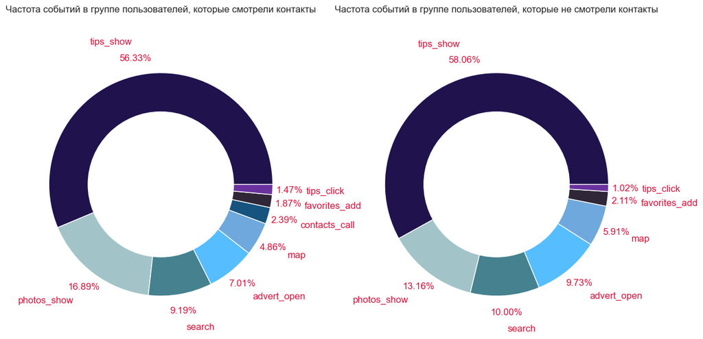

```python
sns.set_style("whitegrid")
custom_palette = sns.color_palette("mako", 9)
sns.set_palette(custom_palette)

self_palette ={'tips_show':'#20124d',
               'map':'#6fa8dc',
               'search':'#45818e',
               'photos_show':'#a2c4c9',
               'favorites_add':'#2f2737',
               'advert_open':'#56bdff',
               'tips_click':'#6a329f',
               'contacts_call':'#16537e'}

tmp = viewed_contacts[viewed_contacts['event_name'] != 'contacts_show']['event_name'].value_counts(normalize=True).reset_index()
tmp2 = not_viewed_contacts['event_name'].value_counts(normalize=True).reset_index()

fig, axs = plt.subplots(1, 2, figsize=(14, 8))

hole = plt.Circle((0, 0), 0.65, facecolor='white')
hole2 = plt.Circle((0, 0), 0.65, facecolor='white')

labels = tmp['index']

axs[0].pie(tmp['event_name'], labels = tmp['index'], autopct='%1.2f%%', textprops={'color':"crimson", 'fontsize': 12}, pctdistance=1.15, labeldistance=1.3, colors=[self_palette[key] for key in labels])
axs[0].set_title('Частота событий в группе пользователей, которые смотрели контакты', y=1.1)
axs[0].add_artist(hole)

labels = tmp2['index']

axs[1].pie(tmp2['event_name'], labels = tmp2['index'], autopct='%1.2f%%', textprops={'color':"crimson", 'fontsize': 12}, pctdistance=1.15, labeldistance=1.3, colors=[self_palette[key] for key in labels])
axs[1].set_title('Частота событий в группе пользователей, которые не смотрели контакты', y=1.1)
axs[1].add_artist(hole2)

plt.show()
```

Можно заметить, что особой разницы нет.

tips_show (просмотр рекомендованного объявления) является самым распространенным действием, оно встречается в более половины случаев.

### Влияет ли источник установки приложения на поведение пользователей?

Изучим как источник установки приложения влияет на поведение пользователей и их действия

```python
df = mobile_dataset.merge(mobile_sourсes, how='left', on='user_id')

df = df.sort_values(by=['user_id', 'event_time'])
tmp = df.groupby(['source', 'event_name']).size().unstack(fill_value=0)
# общее кол-во действий по каналам
total_by_source = df.groupby('source').size()
# доля действий по каналам
channel_fraction = tmp.div(total_by_source, axis=0)
channel_fraction
```

| event_name source | advert_open | contacts_call | contacts_show | favorites_add | map | photos_show | search | tips_click | tips_show |
| --- | --- | --- | --- | --- | --- | --- | --- | --- | --- |
| google | 0.079286 | 0.007973 | 0.070433 | 0.020298 | 0.050281 | 0.169528 | 0.104867 | 0.009293 | 0.488041 |
| other | 0.098531 | 0.007808 | 0.054146 | 0.013305 | 0.046748 | 0.147026 | 0.100586 | 0.011713 | 0.520138 |
| yandex | 0.076562 | 0.006592 | 0.059354 | 0.021671 | 0.056670 | 0.107449 | 0.078224 | 0.011550 | 0.581928 |

- Пользователи, пришедшие из прочих источников, чаще открывают карточки объявления
- Пользователи, пришедшие из google, чаще просматривают контакты и фото. Но реже реагируют на рекомендованное объявление
- Пользователи, пришедшие из yandex, чаще видят рекомендованные объявления и открывают карту. Реже пользуются поиском по сайту

### Различна ли скорость выполнения целевого действия в зависимости от источника установки?

Проанализируем скорость выполнения целевого действия для разных источников

```python
sns.set_style("whitegrid")
custom_palette = sns.color_palette("blend:#20124d,#6fa8dc", 3)
sns.set_palette(custom_palette)
```

```python
# находим сессии, где просмотрели контакты
sessions_viewed_contacts = mobile_dataset[mobile_dataset['event_name'] == 'contacts_show']['session_id'].unique()
viewed_contacts = mobile_dataset[mobile_dataset['session_id'].isin(sessions_viewed_contacts)]

df = viewed_contacts.merge(mobile_sourсes, how='left', on='user_id')

df = df.sort_values(by=['session_id', 'event_time'])

# первое действие в сессии
first_actions = df.groupby('session_id').first().reset_index()
# целевое действие
target_actions = df[df['event_name'] == 'contacts_show'].groupby('session_id').first().reset_index()
# соединим результаты
merged = (first_actions
          .merge(target_actions[['session_id', 'event_time']], on='session_id', how='left', suffixes=('_first', '_target')))
# разница во времени
merged['difference_minutes'] = (merged['event_time_target'] - merged['event_time_first']).dt.total_seconds()/60
```

```python
print('Средняя скорость выполнения целевого действия в минутах: {}'.format(merged['difference_minutes'].mean()))
print('Медиана скорости выполнения целевого действия в минутах: {}'.format(merged['difference_minutes'].median()))
```

```
Средняя скорость выполнения целевого действия в минутах: 27.208405564853845
Медиана скорости выполнения целевого действия в минутах: 3.257468316666667
```

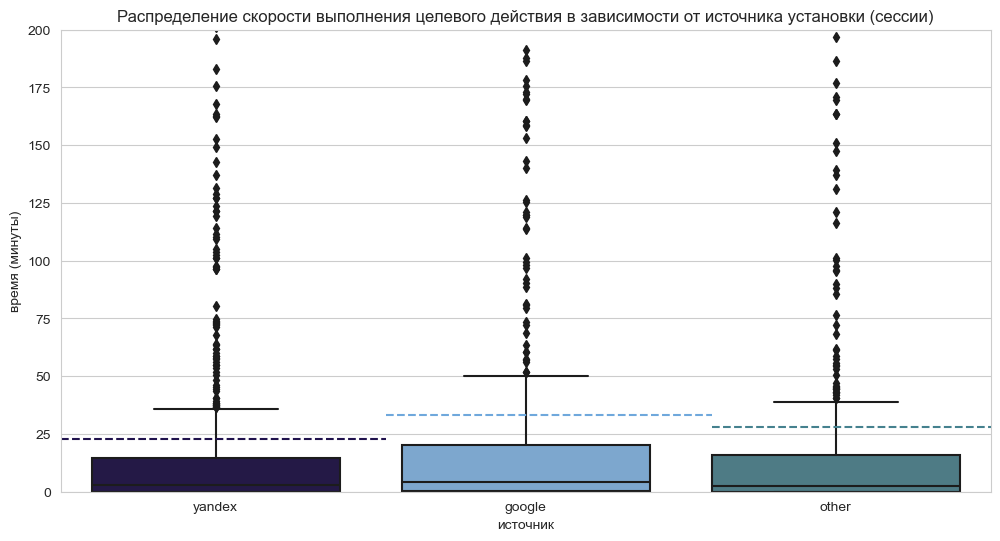

```python
fig, ax = plt.subplots()
fig.set_figheight(6)
fig.set_figwidth(12)

ax = sns.boxplot(x='source', y='difference_minutes', data=merged, palette=["#20124d", "#6fa8dc", "#45818e"])
plt.axhline(y = merged[merged['source'] == 'yandex']['difference_minutes'].mean(), color = "#20124d", ls='dashed', linewidth=1.5, xmax=0.35)
plt.axhline(y =  merged[merged['source'] == 'google']['difference_minutes'].mean(), color = "#6fa8dc", ls='dashed', linewidth=1.5, xmax=0.7, xmin=0.35)
plt.axhline(y =  merged[merged['source'] == 'other']['difference_minutes'].mean(), color = "#45818e", ls='dashed', linewidth=1.5, xmin=0.7)
ax.set_ylim([0,200])
plt.title('Распределение скорости выполнения целевого действия в зависимости от источника установки (сессии)')
plt.xlabel('источник')
plt.ylabel('время (минуты)')
plt.show()
```

- На графике присутствует очень много выбросов
- Распределение для всех трех источников практически идентично
- Среднее время для yandex меньше, чем для других источников
- Медиана времени для источников меньше 10

### Существует ли разница в количестве ежедневных событий среди тех, кто совершил целевое действие, и тех, кто нет?

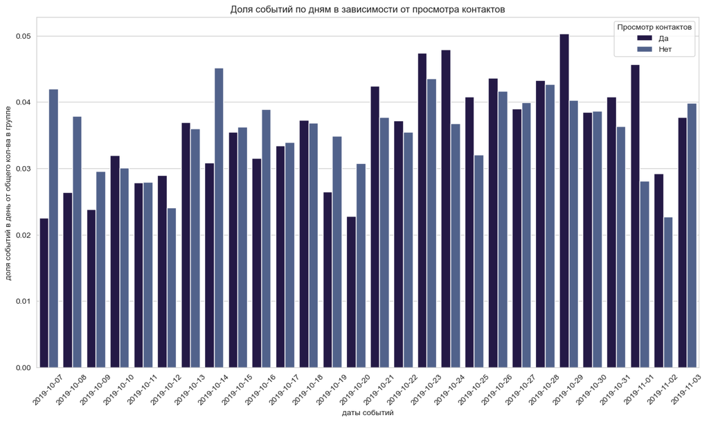

```python
# разделяем пользователей на две группы
viewed_contacts = mobile_dataset[mobile_dataset['user_id'].isin(ids_viewed_contacts)]
not_viewed_contacts = mobile_dataset[~mobile_dataset['user_id'].isin(ids_viewed_contacts)]

df1 = viewed_contacts[viewed_contacts['event_name'] != 'contacts_show'].groupby('date').size().to_frame('size').reset_index()
df1['ds'] = 'viewed contacts'
df2 = not_viewed_contacts.groupby('date').size().to_frame('size').reset_index()
df2['ds'] = 'didn\'t view contacts'
dss = pd.concat([df1, df2])

total1 = dss.groupby('ds')['size'].sum()
dss = dss.merge(total1, on='ds', suffixes=('', '_total'))
dss['fraction'] = dss['size'] / dss['size_total']

plt.figure(figsize=(15, 8))

ax = sns.barplot(x='date', y='fraction', hue='ds', data=dss)

plt.title('Доля событий по дням в зависимости от просмотра контактов')
plt.xlabel('даты событий')
plt.ylabel('доля событий в день от общего кол-ва в группе')
plt.xticks(rotation=45)

h, l = ax.get_legend_handles_labels()
ax.legend(h, ['Да', 'Нет'], title="Просмотр контактов")

plt.show()
```

- Пик активности для посмотревших контакты наблюдается 29 октября
- Во второй половине месяца доли для людей просмотревших контакты выше, чем в первой

### Влияет ли источник установки приложения на поведение пользователей, посмотревших контакты?

Изучим как источник установки приложения влияет на поведение пользователей и их действия среди посмотревших контакты

```python
viewed_contacts = mobile_dataset[mobile_dataset['user_id'].isin(ids_viewed_contacts)]
df = viewed_contacts.merge(mobile_sourсes, how='left', on='user_id')
df = df.sort_values(by=['user_id', 'event_time'])
tmp = df[df['event_name'] != 'contacts_show'].groupby(['source', 'event_name']).size().unstack(fill_value=0)
total_by_source = df[df['event_name'] != 'contacts_show'].groupby('source').size()
# доля действий по каналам
channel_fraction = tmp.div(total_by_source, axis=0)
channel_fraction
```

| event_name source | advert_open | contacts_call | favorites_add | map | photos_show | search | tips_click | tips_show |
| --- | --- | --- | --- | --- | --- | --- | --- | --- |
| google | 0.066450 | 0.023045 | 0.015269 | 0.054008 | 0.154249 | 0.115792 | 0.012018 | 0.559169 |
| other | 0.076203 | 0.029624 | 0.016761 | 0.043266 | 0.234067 | 0.075034 | 0.013643 | 0.511401 |
| yandex | 0.069572 | 0.021598 | 0.021980 | 0.047496 | 0.146789 | 0.084098 | 0.017011 | 0.591456 |

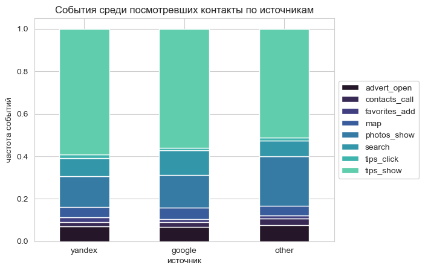

```python
custom_palette = sns.color_palette("mako", 9)
sns.set_palette(custom_palette)

plt.figure(figsize=(10, 4))
channel_fraction.sort_values(by='tips_show', ascending=False).plot(kind='bar', stacked=True)
plt.legend(loc='center left', bbox_to_anchor=(1, 0.5))
plt.xticks(rotation=0)
plt.title('События среди посмотревших контакты по источникам')
plt.xlabel('источник')
plt.ylabel('частота событий')

plt.show()
```

- Пользователи, пришедшие из прочих источников, чаще просматривают фото. Реже всех рекомендованные объявления
- Пользователи, пришедшие из google, чаще пользуются поиском по сайту
- Пользователи, пришедшие из yandex, чаще видят рекомендованные объявления

### Существует ли разница в количестве ежедневных событий среди тех, кто совершил целевое действие, по источникам?

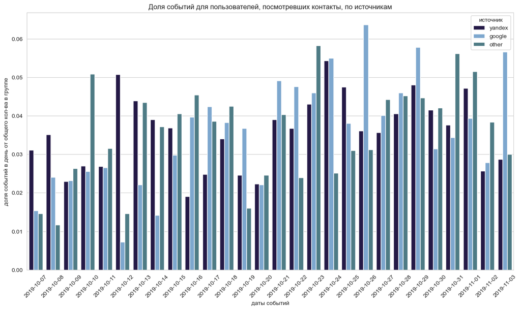

```python
tmp = df[df['event_name'] != 'contacts_show']

df1 = tmp[tmp['source'] == 'yandex'].groupby('date').size().to_frame('size').reset_index()
df1['ds'] = 'yandex'
df2 = tmp[tmp['source'] == 'google'].groupby('date').size().to_frame('size').reset_index()
df2['ds'] = 'google'
df3 = tmp[tmp['source'] == 'other'].groupby('date').size().to_frame('size').reset_index()
df3['ds'] = 'other'
dss = pd.concat([df1, df2, df3])

total1 = dss.groupby('ds')['size'].sum()
dss = dss.merge(total1, on='ds', suffixes=('', '_total'))
dss['fraction'] = dss['size'] / dss['size_total']

plt.figure(figsize=(15, 8))

ax = sns.barplot(x='date', y='fraction', hue='ds', data=dss, palette=["#20124d", "#6fa8dc", "#45818e"])

plt.title('Доля событий для пользователей, посмотревших контакты, по источникам')
plt.xlabel('даты событий')
plt.ylabel('доля событий в день от общего кол-ва в группе')
plt.xticks(rotation=45)
plt.legend(title="источник")

plt.show()
```

### Вывод:

**Есть ли различия в частоте событий между группами пользователей?**

- Особой разницы нет. Кроме того, tips_show (просмотр рекомендованного объявления) является наиболее распространенным действием, встречаясь в более чем половине случаев.

**Влияет ли источник установки приложения на поведение пользователей?**

- Пользователи из прочих источников чаще открывают карточки объявлений.
- Пользователи из Google чаще просматривают контакты и фото, но реже реагируют на рекомендованные объявления.
- Пользователи из Yandex чаще видят рекомендованные объявления и открывают карту, но реже пользуются поиском по сайту.

**Различна ли скорость выполнения целевого действия в зависимости от источника установки?**

- Среднее время до выполнения целевого действия для пользователей из Yandex меньше, чем для других источников.

**Существует ли разница в количестве ежедневных событий среди тех, кто совершил целевое действие, и тех, кто нет?**

- Пик активности для посмотревших контакты наблюдается 29 октября
- Во второй половине месяца доли для людей просмотревших контакты выше, чем в первой

**Влияет ли источник установки приложения на поведение пользователей, посмотревших контакты?**

- Пользователи из прочих источников чаще просматривают фото и реже видят рекомендованные объявления.
- Пользователи из Google чаще пользуются поиском по сайту.
- Пользователи из Yandex чаще видят рекомендованные объявления.

## Статистические гипотезы

Используем z-статистику для проверки разницы в конверсии в просмотры контактов для пользователей, которые совершают действия tips_show и tips_click, по сравнению с теми, кто совершает только tips_show.

*H0: доля посмотревших контакты среди тех, кто совершил оба действия = доле посмотревших контакты среди тех, кто совершил лишь одно действие*

*Ha: доля посмотревших контакты среди тех, кто совершил оба действия != доле посмотревших контакты среди тех, кто совершил лишь одно действие*

Уровень статистической значимости = 5%

```python
# пользователи, которые совершили tips_show и tips_click
both_actions = mobile_dataset[mobile_dataset['event_name'].isin(['tips_show', 'tips_click'])].groupby('user_id')['event_name'].nunique()
both_actions = both_actions[both_actions > 1].index
# пользователи, которые совершили только tips_show
single_action = mobile_dataset[mobile_dataset['event_name'] == 'tips_show']['user_id'].unique()
single_action = set(single_action) - set(both_actions)
# пользователи, которые совершили просмотры контактов
contact_users = mobile_dataset[mobile_dataset['event_name'] == 'contacts_show']['user_id'].unique()

num_both = len(set(both_actions) & set(contact_users))
num_both_total = len(both_actions)
num_single = len(set(single_action) & set(contact_users))
num_single_total = len(single_action)

alpha = 0.05

p1 = num_both / num_both_total
p2 = num_single / num_single_total
p_combined = (num_both + num_single) / (num_both_total + num_single_total)
diff = p1 - p2

z_value = diff / mth.sqrt(p_combined * (1 - p_combined) * (1 / num_both_total + 1 / num_single_total))

distr = st.norm(0,1)

p_value = (1 - distr.cdf(abs(z_value))) * 2

print('p-значение: ', p_value)

if p_value < alpha:
    print('Отвергаем нулевую гипотезу: между долями есть значимая разница\n')
else:
    print('Не получилось отвергнуть нулевую гипотезу, нет оснований считать доли разными\n')

print('Конверсия в просмотры контактов для пользователей с tips_show и tips_click: {:.2%}'.format(p1))
print('Конверсия в просмотры контактов для пользователей с tips_show: {:.2%}'.format(p2))
```

```
p-значение:  9.218316554537864e-09
Отвергаем нулевую гипотезу: между долями есть значимая разница

Конверсия в просмотры контактов для пользователей с tips_show и tips_click: 30.64%
Конверсия в просмотры контактов для пользователей с tips_show: 16.97%
```

**Вывод:** Таким образом, при alpha=5% у нас не получается сделать вывод о том, что конверсия в просмотры контактов среди двух групп пользователей одинакова.

Чтобы проверить различается ли среднее время, прошедшее с начала сессии до просмотра контактов, для пользователей из разных источников установки, будем использовать непараметрический тест Краскела — Уоллиса, т.к. у нас 3 выборки.

*H0: Медиана прошедшего времени одинакова для всех источников*

*Ha: Медиана прошедшего времени не одинакова для всех источников*

Уровень статистической значимости = 5%

```python
data_yandex = merged[merged['source'] == 'yandex']['difference_minutes']
data_google = merged[merged['source'] == 'google']['difference_minutes']
data_other = merged[merged['source'] == 'other']['difference_minutes']

result = st.kruskal(data_yandex, data_google, data_other)

p_value = result.pvalue

print('p-значение: ', p_value)

if p_value < alpha:
    print('Отвергаем нулевую гипотезу: разница статистически значима')
else:
    print('Не получилось отвергнуть нулевую гипотезу, вывод о различии сделать нельзя')

res = sp.posthoc_dunn([data_yandex, data_google, data_other], p_adjust = 'bonferroni')
print(res < alpha)
```

```
p-значение:  0.02848763429667397
Отвергаем нулевую гипотезу: разница статистически значима
       1      2      3
1  False  False  False
2  False  False   True
3  False   True  False
```

**Вывод:** Таким образом, при alpha=5% у нас не получается сделать вывод о том, что среднее время, прошедшее с начала сессии до просмотра контактов, для пользователей из разных источников (yandex, google и прочие) установки одинаково. Существует разница между google и прочими источниками.

## Общий вывод

Основываясь на результатах исследования, предлагаю следующие рекомендации: